# Trabajo práctico N° 1: Mapas perceptuales

Melina Schamberger

16/5/2022

# Análisis factorial

### Problema gerencial

La empresa deportiva Shoetas desea evaluar el **grado de fidelidad de los consumidores hacia las zapatillas Shoetas**. Se entrevistaron a 189 consumidores, en los que se midió la fidelidad cognitiva y la fidelidad afectiva.

La **fidelidad cognitiva** se midió evaluando seis declaraciones en una escala de Likert de 5 puntos, que van desde 1 = completamente en desacuerdo hasta 5 = completamente de acuerdo.

Los enunciados utilizados en el cuestionario son los siguientes:

- Es preferible utilizar zapatillas Shoetas (CLOY1).
- Las características de las zapatillas de Shoetas se corresponden globalmente con mis expectativas (CLOY2).
- Si alguien me propone que use otra marca de zapatillas, seguiré usando Shoetas por su diseño (CLOY3).
- Si alguien me propone que use otra marca de zapatillas, seguiré usando Shoetas por su durabilidad (CLOY4).
- Si alguien me propone que use otra marca de zapatillas, seguiré usando Shoetas por su calidad (CLOY5).
- Si alguien me propone que use otra marca de zapatillas, seguiré usando Shoetas por su precio (CLOY6).

La **fidelidad afectiva** se midió calificando tres afirmaciones en una escala de Likert de 5 puntos, que van desde = 1 completamente en desacuerdo hasta 5 = completamente de acuerdo.

Las afirmaciones utilizadas en el cuestionario son las siguientes:

- Me gustan más los trianers de Shoetas que otras zapatillas (ALOY1).
- Me gustan las características de mis zapatillas Shoetas (ALOY2).
- Tengo una actitud positiva hacia las zapatillas Shoetas (ALOY3).

Se muestran a continuación las primeras seis filas del conjunto de datos. Se observa que todos son numéricos:

| ALOY1 | ALOY2 | ALOY3 | CLOY1 | CLOY2 | CLOY3 | CLOY4 | CLOY5 | CLOY6 | id |
| --- | --- | --- | --- | --- | --- | --- | --- | --- | --- |
| 5 | 5 | 5 | 5 | 5 | 5 | 5 | 5 | 5 | 1 |
| 4 | 5 | 3 | 5 | 5 | 5 | 4 | 4 | 4 | 2 |
| 3 | 4 | 3 | 4 | 4 | 4 | 4 | 4 | 3 | 3 |
| 4 | 4 | 4 | 4 | 4 | 4 | 4 | 4 | 4 | 4 |
| 3 | 3 | 3 | 2 | 3 | 2 | 2 | 2 | 3 | 5 |
| 3 | 3 | 3 | 3 | 3 | 3 | 3 | 3 | 3 | 6 |

En primera instancia, se realiza un análisis exploratorio de los datos:

```r
kable_styling(kable(summary(Datos)))
```

|  | ALOY1 | ALOY2 | ALOY3 | CLOY1 | CLOY2 | CLOY3 | CLOY4 | CLOY5 | CLOY6 | id |
| --- | --- | --- | --- | --- | --- | --- | --- | --- | --- | --- |
|  | Min. :1.000 | Min. :1.00 | Min. :1.000 | Min. :2.000 | Min. :1.000 | Min. :1.000 | Min. :1.000 | Min. :1.000 | Min. :1.000 | Min. : 1 |
|  | 1st Qu.:4.000 | 1st Qu.:4.00 | 1st Qu.:3.000 | 1st Qu.:4.000 | 1st Qu.:4.000 | 1st Qu.:4.000 | 1st Qu.:4.000 | 1st Qu.:4.000 | 1st Qu.:3.000 | 1st Qu.: 48 |
|  | Median :4.000 | Median :4.00 | Median :4.000 | Median :4.000 | Median :4.000 | Median :4.000 | Median :4.000 | Median :4.000 | Median :4.000 | Median : 95 |
|  | Mean :4.148 | Mean :4.28 | Mean :3.783 | Mean :4.275 | Mean :4.095 | Mean :4.175 | Mean :4.074 | Mean :4.169 | Mean :4.058 | Mean : 95 |
|  | 3rd Qu.:5.000 | 3rd Qu.:5.00 | 3rd Qu.:5.000 | 3rd Qu.:5.000 | 3rd Qu.:5.000 | 3rd Qu.:5.000 | 3rd Qu.:5.000 | 3rd Qu.:5.000 | 3rd Qu.:5.000 | 3rd Qu.:142 |
|  | Max. :5.000 | Max. :5.00 | Max. :5.000 | Max. :5.000 | Max. :5.000 | Max. :5.000 | Max. :5.000 | Max. :5.000 | Max. :5.000 | Max. :189 |

Si bien todos poseen la misma escala de medición, se estandarizan para facilitar su análisis. Se suprime la columna identificatoria de los casos.

```r
Datos.sc <- data.frame(scale(Datos[, 1:9]))
kable_styling(kable(summary(Datos.sc)))
```

|  | ALOY1 | ALOY2 | ALOY3 | CLOY1 | CLOY2 | CLOY3 | CLOY4 | CLOY5 | CLOY6 |
| --- | --- | --- | --- | --- | --- | --- | --- | --- | --- |
|  | Min. :-3.7310 | Min. :-4.0370 | Min. :-3.0941 | Min. :-3.1561 | Min. :-3.9022 | Min. :-4.0201 | Min. :-3.71160 | Min. :-3.8624 | Min. :-3.64474 |
|  | 1st Qu.:-0.1756 | 1st Qu.:-0.3451 | 1st Qu.:-0.8706 | 1st Qu.:-0.3817 | 1st Qu.:-0.1201 | 1st Qu.:-0.2211 | 1st Qu.:-0.08944 | 1st Qu.:-0.2063 | 1st Qu.:-1.26116 |
|  | Median :-0.1756 | Median :-0.3451 | Median : 0.2412 | Median :-0.3817 | Median :-0.1201 | Median :-0.2211 | Median :-0.08944 | Median :-0.2063 | Median :-0.06936 |
|  | Mean : 0.0000 | Mean : 0.0000 | Mean : 0.0000 | Mean : 0.0000 | Mean : 0.0000 | Mean : 0.0000 | Mean : 0.00000 | Mean : 0.0000 | Mean : 0.00000 |
|  | 3rd Qu.: 1.0096 | 3rd Qu.: 0.8855 | 3rd Qu.: 1.3529 | 3rd Qu.: 1.0056 | 3rd Qu.: 1.1406 | 3rd Qu.: 1.0452 | 3rd Qu.: 1.11795 | 3rd Qu.: 1.0124 | 3rd Qu.: 1.12243 |
|  | Max. : 1.0096 | Max. : 0.8855 | Max. : 1.3529 | Max. : 1.0056 | Max. : 1.1406 | Max. : 1.0452 | Max. : 1.11795 | Max. : 1.0124 | Max. : 1.12243 |

Seguidamente, se analiza la matriz de correlación de las variables.

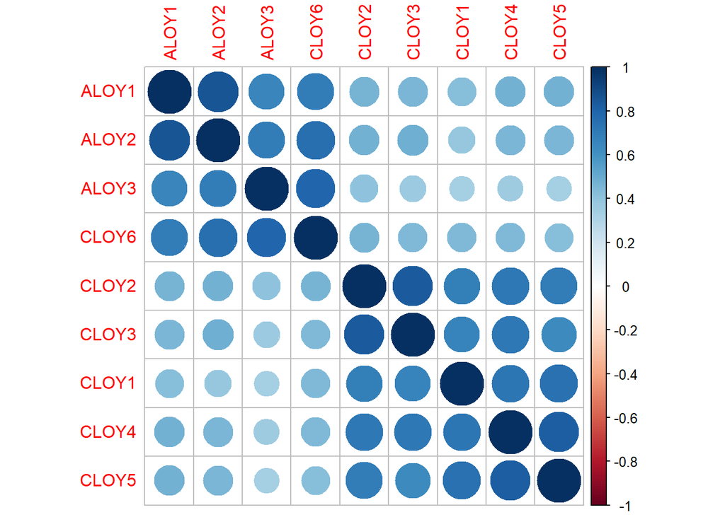

```r
corrplot(cor(Datos.sc[, 1:9]), order="hclust")
```

Entre las variables vinculadas a la fidelidad afectiva, se observa que existe mayor correlación entre la variable que mide la preferencia por las zapatillas (ALOY1) y aquella que alude a la valoración de las características de las zapatillas(ALOY2).

Entre las variables vinculadas a la fidelidad cognitiva, se aprecia notable correlación entre la valoración del cumplimiento de las expectactivas (CLOY2) y su diseño (CLOY3) por un lado; y entre la valoración de la durabilidad (CLOY4) y la calidad (CLOY5), por otro.

Finalmente, entre los dos tipos de variables se observa significativa correlación entre:

- la valoración de las características de las zapatillas (ALOY2) y la del precio (CLOY6),
- la valoración de la actitud positiva vinculada a las zapatillas (ALOY3) y la del precio (CLOY6).

Se presenta la matriz de correlación de los atributos:

```r
kable_styling(kable((cor(Datos.sc[, 1:9]))))
```

|  | ALOY1 | ALOY2 | ALOY3 | CLOY1 | CLOY2 | CLOY3 | CLOY4 | CLOY5 | CLOY6 |
| --- | --- | --- | --- | --- | --- | --- | --- | --- | --- |
| ALOY1 | 1.0000000 | 0.8545026 | 0.6522943 | 0.4223472 | 0.4635947 | 0.4559047 | 0.4713330 | 0.4783059 | 0.6939728 |
| ALOY2 | 0.8545026 | 1.0000000 | 0.6949712 | 0.3851824 | 0.4782484 | 0.4869592 | 0.4510812 | 0.4549239 | 0.7560715 |
| ALOY3 | 0.6522943 | 0.6949712 | 1.0000000 | 0.3304373 | 0.4018723 | 0.3681233 | 0.3501215 | 0.3382991 | 0.7920675 |
| CLOY1 | 0.4223472 | 0.3851824 | 0.3304373 | 1.0000000 | 0.6888314 | 0.6626836 | 0.7229597 | 0.7481406 | 0.4482650 |
| CLOY2 | 0.4635947 | 0.4782484 | 0.4018723 | 0.6888314 | 1.0000000 | 0.8309827 | 0.7178963 | 0.6942620 | 0.4631558 |
| CLOY3 | 0.4559047 | 0.4869592 | 0.3681233 | 0.6626836 | 0.8309827 | 1.0000000 | 0.7120604 | 0.6354653 | 0.4421570 |
| CLOY4 | 0.4713330 | 0.4510812 | 0.3501215 | 0.7229597 | 0.7178963 | 0.7120604 | 1.0000000 | 0.8267368 | 0.4453504 |
| CLOY5 | 0.4783059 | 0.4549239 | 0.3382991 | 0.7481406 | 0.6942620 | 0.6354653 | 0.8267368 | 1.0000000 | 0.4259745 |
| CLOY6 | 0.6939728 | 0.7560715 | 0.7920675 | 0.4482650 | 0.4631558 | 0.4421570 | 0.4453504 | 0.4259745 | 1.0000000 |

Seguidamente, se realiza un mapa de calor para observar cómo se relacionan los atributos.

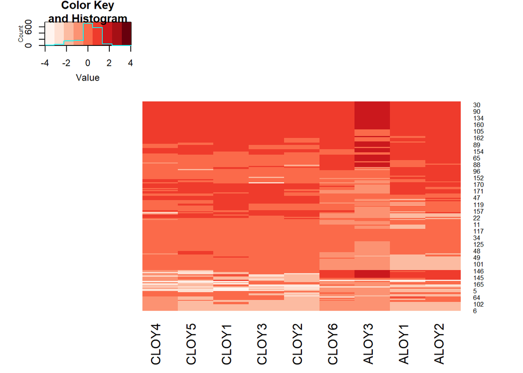

```r
heatmap.2(as.matrix(Datos.sc),
          col=brewer.pal(9, "Reds"), trace="none", key=TRUE, dend="none")
```

A los fines de avanzar en el análisis factorial, se verifica si es conveniente aplicar esta técnica mediante el Test de Bartlet.

```r
mat_cor<-data.frame(cor(Datos.sc))
cortest.bartlett(mat_cor,n=189)
```

```
## $chisq
## [1] 1458.09
##
## $p.value
## [1] 3.203898e-283
##
## $df
## [1] 36
```

Con el **p-value < 0.05** se rechaza la hipótesis nula (varianzas homogéneas) y se procede a realizar la medida de adecuación muestral KMO (Kaiser-Meyer-Olkin).

```r
KMO(Datos.sc)
```

```
## Kaiser-Meyer-Olkin factor adequacy
## Call: KMO(r = Datos.sc)
## Overall MSA =  0.86
## MSA for each item =
## ALOY1 ALOY2 ALOY3 CLOY1 CLOY2 CLOY3 CLOY4 CLOY5 CLOY6
##  0.85  0.82  0.86  0.92  0.88  0.85  0.89  0.86  0.86
```

Se obtiene un **KMO = 0.86** que evidencia la pertinencia de emplear el análisis factorial para explorar los atributos de las zapatillas.

Habiendo verificado la validez de la técnica, se escoge el *método de componentes principales* para extrar los factores.

```r
Datos.pc <- prcomp(Datos.sc[, 1:9])
summary(Datos.pc)
```

```
## Importance of components:
##                           PC1    PC2     PC3     PC4     PC5     PC6     PC7
## Standard deviation     2.3473 1.2743 0.69432 0.66346 0.53794 0.45382 0.42465
## Proportion of Variance 0.6122 0.1804 0.05357 0.04891 0.03215 0.02288 0.02004
## Cumulative Proportion  0.6122 0.7926 0.84619 0.89510 0.92725 0.95013 0.97017
##                            PC8     PC9
## Standard deviation     0.38314 0.34880
## Proportion of Variance 0.01631 0.01352
## Cumulative Proportion  0.98648 1.00000
```

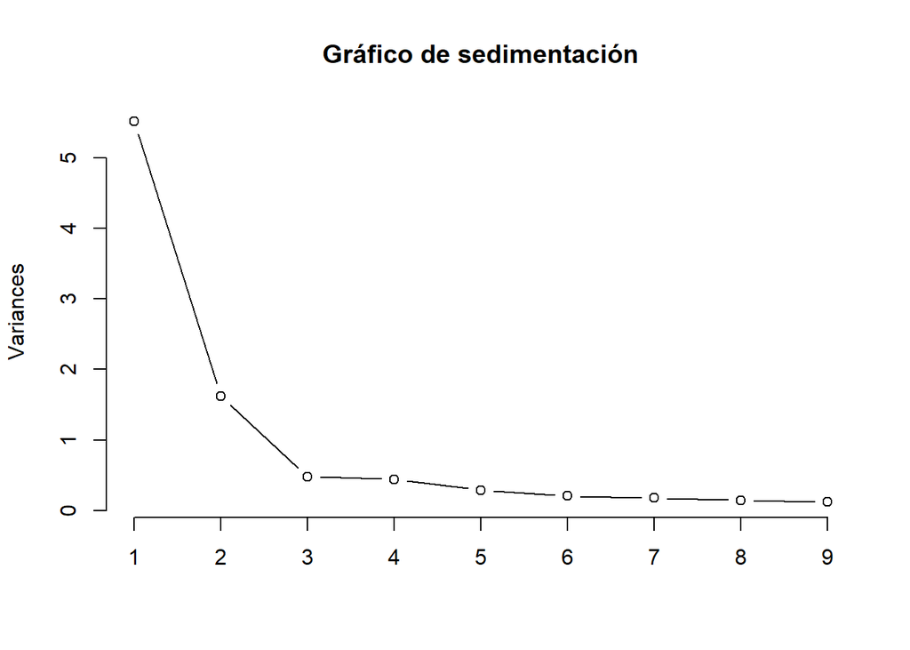

```r
plot(Datos.pc, type="l", main = "Gráfico de sedimentación")
```

La **varianza acumulada > 0.80** en 3 componentes, aunque la **DS > 1** en sólo 2.

El gráfico de sedimentación indica que sólo son mayores que 1 los autovalores de las dos primeras variables, con lo que estas dos variables resumirán al resto representándolas de forma coherente, es decir, serán las 2 componentes principales que resumen toda la información.

Se procede a realizar un biplot para ver cómo se distribuyen las respuestas.

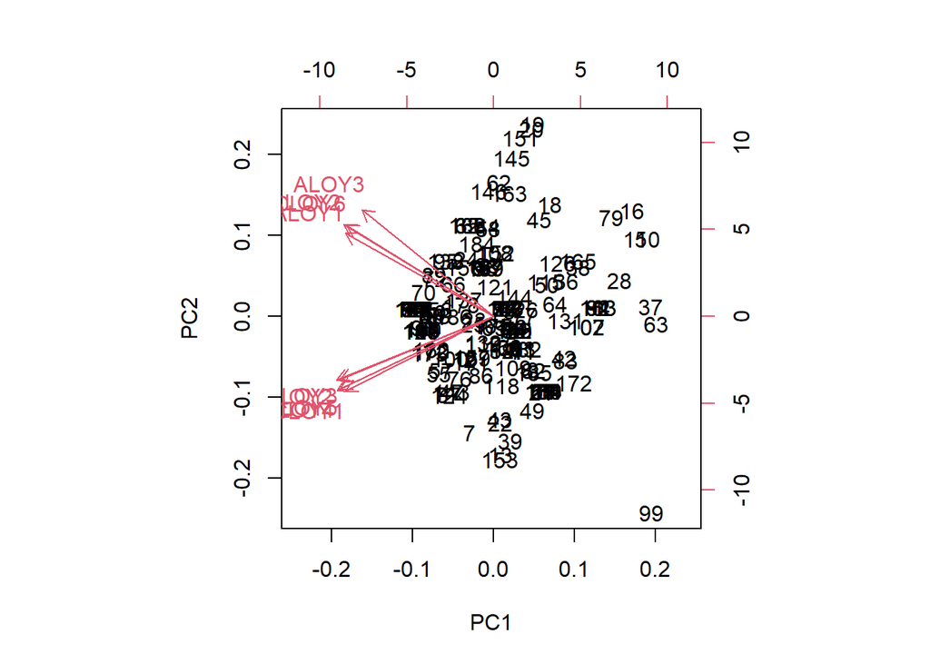

```r
biplot(Datos.pc)
```

Así, se avanza en realizar el análisis factorial exploratorio.

```r
nScree(data.frame(Datos.sc[, 1:9]))
```

```
##   noc naf nparallel nkaiser
## 1   2   1         2       2
```

Del Scree plot surge que lo conveniente podría ser extrar 2 factores:

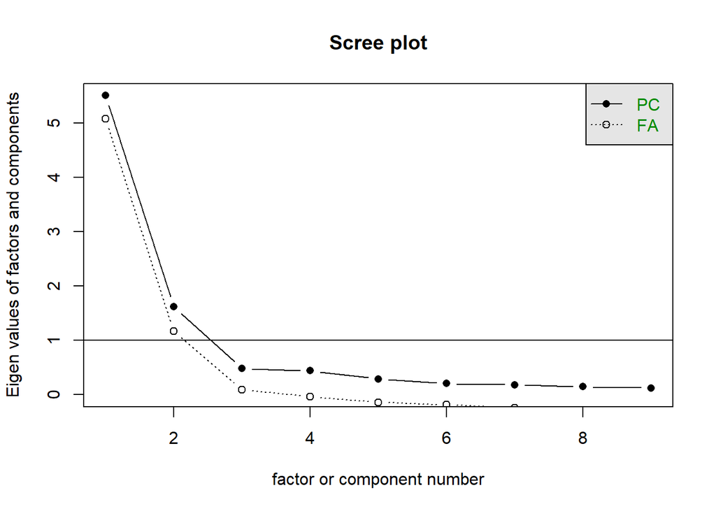

```r
scree(Datos.sc[, 1:9])
```

```r
eigen(cor(Datos.sc[, 1:9]))
```

```
## eigen() decomposition
## $values
## [1] 5.5098814 1.6237286 0.4820859 0.4401793 0.2893816 0.2059538 0.1803314
## [8] 0.1467983 0.1216596
##
## $vectors
##             [,1]       [,2]        [,3]         [,4]        [,5]        [,6]
##  [1,] -0.3301171 -0.3411057  0.21583769  0.513355328  0.19219336  0.21788717
##  [2,] -0.3340774 -0.3779836  0.04280657  0.417532801  0.06241108 -0.12104156
##  [3,] -0.2926799 -0.4366218 -0.14587272 -0.510398767 -0.27681348  0.48858802
##  [4,] -0.3297481  0.3077233  0.23827156 -0.322523659  0.74877438  0.08425939
##  [5,] -0.3504813  0.2619504 -0.48336607  0.053667913 -0.03842030  0.32355544
##  [6,] -0.3416527  0.2582582 -0.58471172  0.180573728  0.02338267 -0.22646331
##  [7,] -0.3482747  0.3037055  0.26361597  0.004848457 -0.47859480 -0.34402261
##  [8,] -0.3422103  0.2970512  0.47747882 -0.010904116 -0.29345544  0.23091770
##  [9,] -0.3271891 -0.3736994 -0.02279367 -0.402460846  0.06845323 -0.60366210
##             [,7]         [,8]        [,9]
##  [1,]  0.1892345  0.364854324  0.45957427
##  [2,] -0.1380196 -0.355396485 -0.63675144
##  [3,]  0.3334972 -0.105311462 -0.06526315
##  [4,]  0.1842492 -0.005753169 -0.18448331
##  [5,] -0.4951535  0.437516093 -0.17105654
##  [6,]  0.3379657 -0.422155399  0.31275077
##  [7,]  0.3926143  0.385501627 -0.25843532
##  [8,] -0.3851210 -0.443506929  0.28651716
##  [9,] -0.3716327  0.120439381  0.26285252
```

Se realiza el **análisis factorial con 2 factores**.

```r
factanal(Datos.sc[, 1:9], factors=2)
```

```
##
## Call:
## factanal(x = Datos.sc[, 1:9], factors = 2)
##
## Uniquenesses:
## ALOY1 ALOY2 ALOY3 CLOY1 CLOY2 CLOY3 CLOY4 CLOY5 CLOY6
## 0.211 0.125 0.396 0.316 0.285 0.328 0.203 0.241 0.314
##
## Loadings:
##       Factor1 Factor2
## ALOY1 0.308   0.833
## ALOY2 0.278   0.893
## ALOY3 0.208   0.749
## CLOY1 0.801   0.205
## CLOY2 0.795   0.287
## CLOY3 0.767   0.290
## CLOY4 0.861   0.238
## CLOY5 0.836   0.243
## CLOY6 0.305   0.770
##
##                Factor1 Factor2
## SS loadings      3.612   2.969
## Proportion Var   0.401   0.330
## Cumulative Var   0.401   0.731
##
## Test of the hypothesis that 2 factors are sufficient.
## The chi square statistic is 135.66 on 19 degrees of freedom.
## The p-value is 1.23e-19
```

```r
(Datos.fa.ob <- factanal(Datos.sc[, 1:9], factors=2, rotation="varimax"))
```

```
##
## Call:
## factanal(x = Datos.sc[, 1:9], factors = 2, rotation = "varimax")
##
## Uniquenesses:
## ALOY1 ALOY2 ALOY3 CLOY1 CLOY2 CLOY3 CLOY4 CLOY5 CLOY6
## 0.211 0.125 0.396 0.316 0.285 0.328 0.203 0.241 0.314
##
## Loadings:
##       Factor1 Factor2
## ALOY1 0.308   0.833
## ALOY2 0.278   0.893
## ALOY3 0.208   0.749
## CLOY1 0.801   0.205
## CLOY2 0.795   0.287
## CLOY3 0.767   0.290
## CLOY4 0.861   0.238
## CLOY5 0.836   0.243
## CLOY6 0.305   0.770
##
##                Factor1 Factor2
## SS loadings      3.612   2.969
## Proportion Var   0.401   0.330
## Cumulative Var   0.401   0.731
##
## Test of the hypothesis that 2 factors are sufficient.
## The chi square statistic is 135.66 on 19 degrees of freedom.
## The p-value is 1.23e-19
```

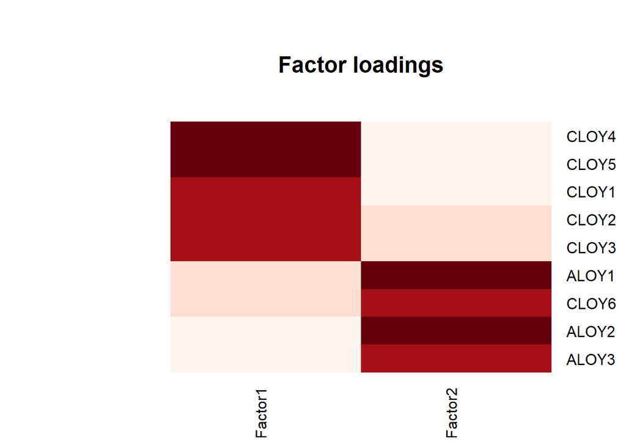

```r
heatmap.2(Datos.fa.ob$loadings,
          col=brewer.pal(9, "Reds"), trace="none", key=FALSE, dend="none",
          Colv=FALSE, cexCol = 1.2,
          main="\n\nFactor loadings")
```

Se observa que, con 2 factores, se alcanza un **73% de la varianza acumulada**.

Se analiza la estructura de los factores de manera gráfica:

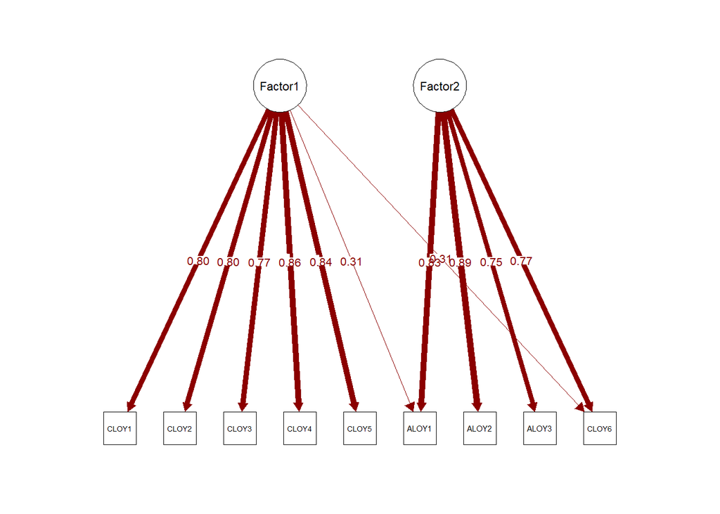

```r
semPaths(Datos.fa.ob, what="est", residuals=FALSE,
         cut=0.3, posCol=c("white", "darkred"), negCol=c("white", "red"),
         edge.label.cex=0.75, nCharNodes=7)
```

Se calculan las puntuaciones factoriales mediante el **método de Bartlett**:

```r
Datos.fa.ob.4 <- factanal(Datos.sc[, 1:9], factors=2, rotation="oblimin",
                        scores="Bartlett")
Datos.scores <- data.frame(Datos.fa.ob.4$scores)
Datos.scores$Datos <- Datos.sc$Datos
head(Datos.scores)
```

```
##      Factor1    Factor2
## 1  1.2450722  1.1416038
## 2  0.5221808  0.3019929
## 3 -0.2386911 -0.9095734
## 4 -0.2214077 -0.2086002
## 5 -2.8948231 -1.5443371
## 6 -1.6878876 -1.5588041
```

Finalmente, se analizan los factores con distintos tipos de rotación:

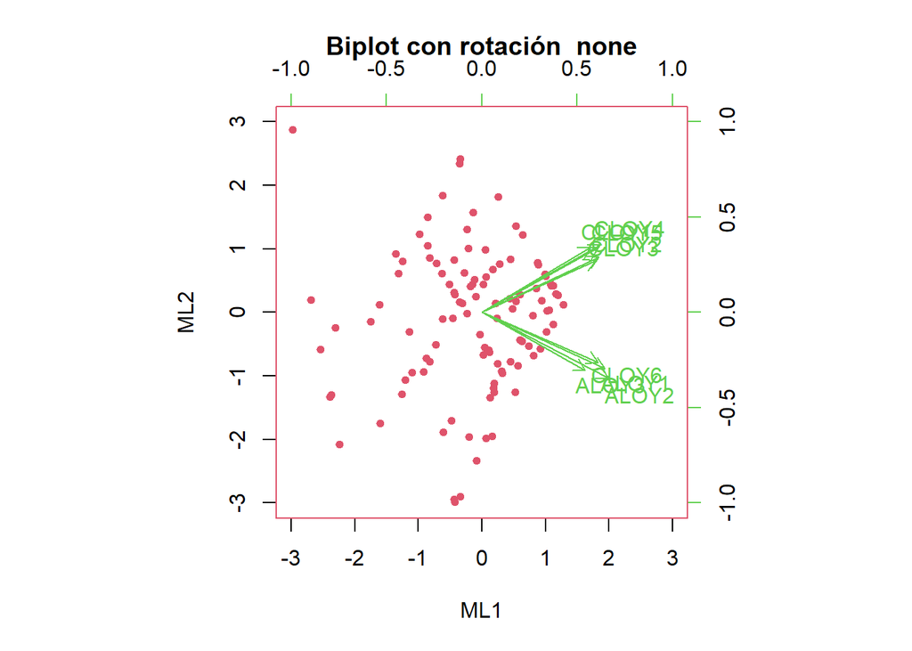

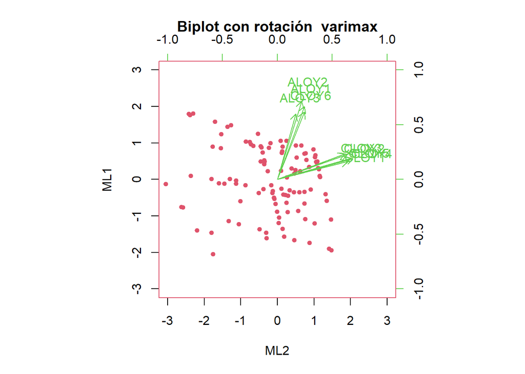

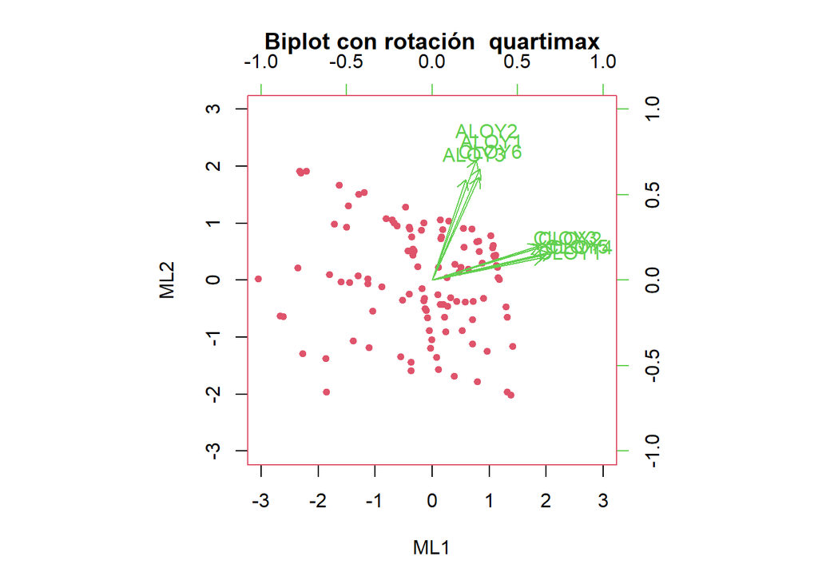

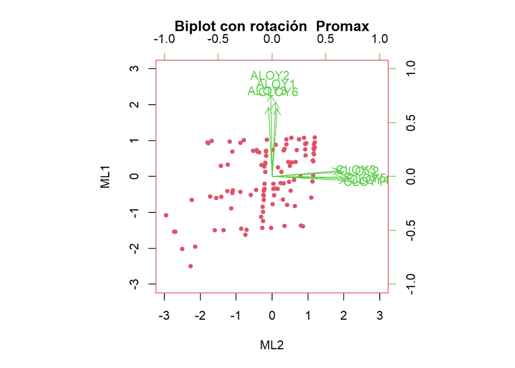

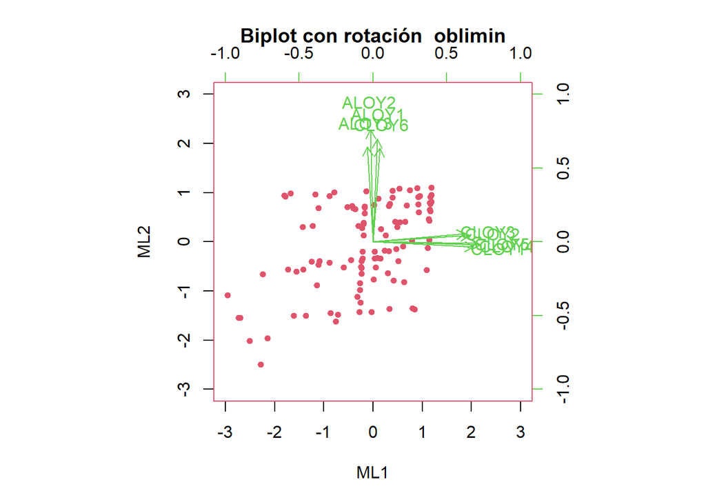

```r
rot<-c("none", "varimax", "quartimax","Promax", "oblimin")
bi_mod<-function(tipo){
biplot.psych(fa(Datos.sc, nfactors=2, rotate=tipo, fm="mle"),
             cex=c(1.5, 1),cuts=c(0),
             main = paste("Biplot con rotación ", tipo),
             col=c(2,3,4), pch = c(21,18)
             #labels = brand.mean[,"brand"],
             )
}
require(graphics)
options(repr.plot.width = 8, repr.plot.height = 10)
sapply(rot,bi_mod)
```

Se decide preservar la última rotación evaluada *(oblimin)*, dado que propone una asociación más nítida de cada una de las variables con el factor correspondiente.

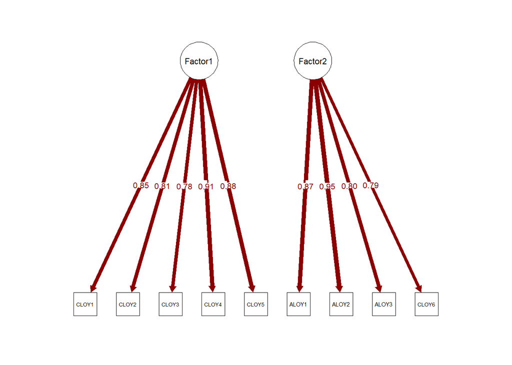

```r
semPaths(Datos.fa.ob.4, what="est", residuals=FALSE,
         cut=0.3, posCol=c("white", "darkred"), negCol=c("white", "red"),
         edge.label.cex=0.75, nCharNodes=7)
```

El análisis realizado sugiere que existen dos perfiles vinculados a la valoración de las zapatillas: uno que prioriza aspectos vinculados a la **fidelidad cognitiva** y parece más conservador en su compra, buscando que responda a sus expectativas, sea de calidad y durable (Factor 1); y otro que pone énfasis en el precio de las zapatiillas y en variables vinculadas a la **fidelidad afectiva**, pudiendo asociarse a un público moderno o jóven que prioriza la actitud asociada al producto y las características que presenta (Factor 2).